# Political Lean has No Impact on Support for Paying College Athletes

Sarah Tritschler and Harrison Miller

12/9/2019

tl;dr

By looking at tweets about the recent bill passed in California that would allow college athletes to benefit monetarily off of their name, likeness, and image, we found that there is no defined relationship between sentiment towards the topic and political leaning based on location. However, when the state is defined by its most popular sport, we can see that basketball players should not go to Democratic states if they want to get “paid to play” because Democratic states whose favorite sport is basketball have the most negative attitudes towards the idea of paying college athletes.

# The Problem

For this project, we decided to look at the way people in different regions have talked about the idea of college athletes getting paid. Earlier in November, California governor Gavin Newsom approved a bill that would allow college athletes to benefit from their “name, likeness, and image.” This is very controversial as it monetizes college athletics. Certain states in the US are known to be ‘Republican’ or ‘Democratic’ based on their political leaning. We want to investigate how Twitter users have talked about college athletes getting paid compared to where they live and see if there is a relationship between political lean and opinion about college athletes being compensated.

# The Data

In order to get our dataset of tweets about this topic, we filtered through all tweets that have been sent out in the last few years using keywords and phrases related to the topic of paying college athletes such as “paying college athletes” and “college athlete endorsement,” with many more keywords and phrases in every thinkable version of wording of those keywords and phrases.

# The Figures

Our first graph shows how often this issue has been talked about over the last few years. You can see that the frequency of this topic has increased over time with a large spike in October of 2019, the month when Gavin Newsom approved the California bill.

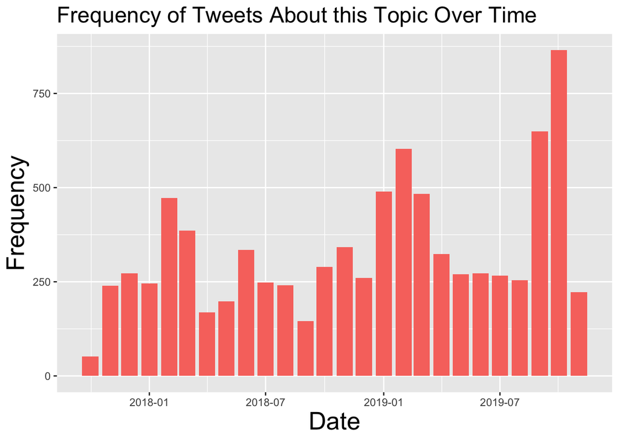

This next graph shows WHERE the tweets were sent out across the United States. From this graph, you can see that tweets about this topic are fairly spread out across the United States, with clumps around major US cities such as San Francisco, Los Angeles, and New York City.

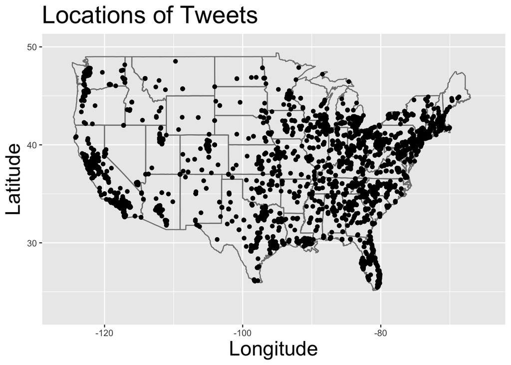

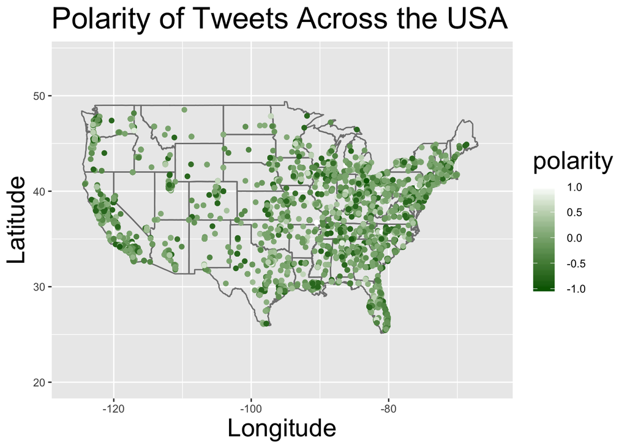

This next graph shows the polarity across the United States when split into positive (polarity > 0) and negative (polarity < 0) tweets, in an effort to make the geographical polarity more clear.

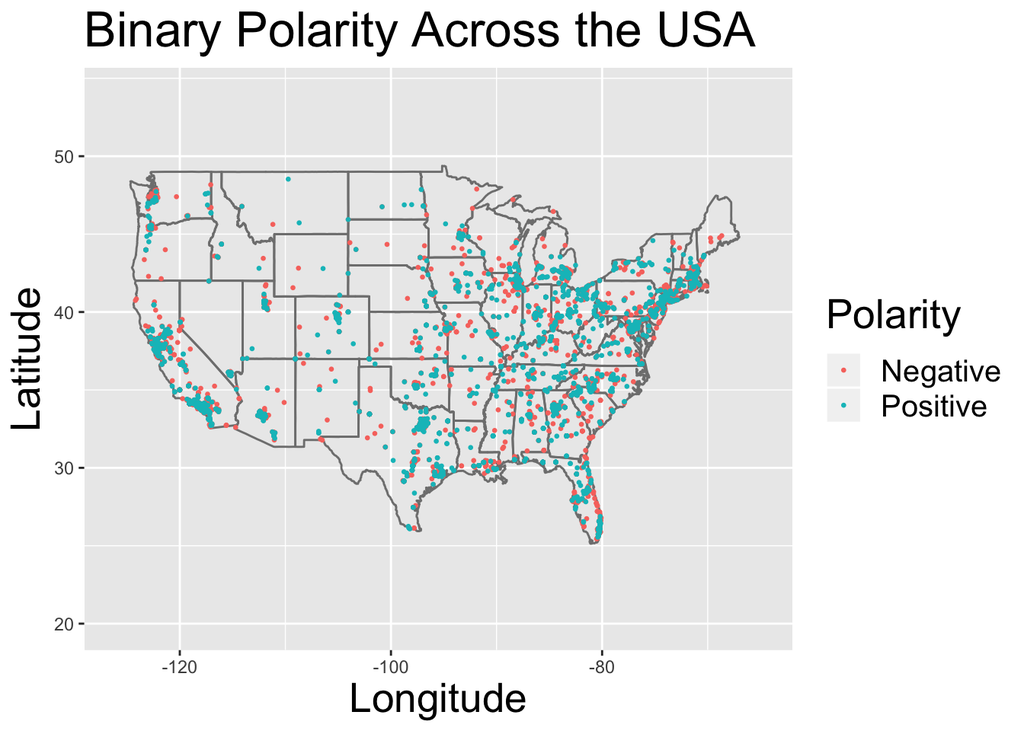

Since it is difficult to see the true comparison of positive versus negative because many of the dots are from the same place, let’s split this into two separate maps, one for positive and one for negative.

These two graphs show the polarity when split into positive and negative. As you can see, the positive (teal) map has clusters in the same areas as the negative (red) map, further pushing us towards the conclusion that location has no real relationship with attitude towards the concept of paying college athletes.

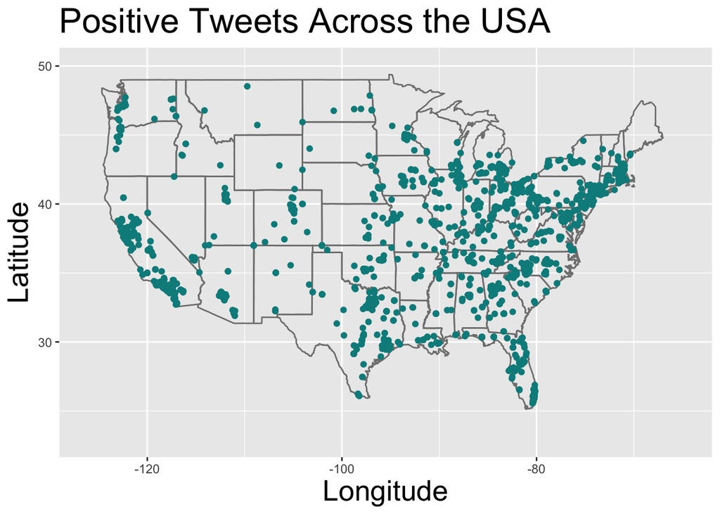

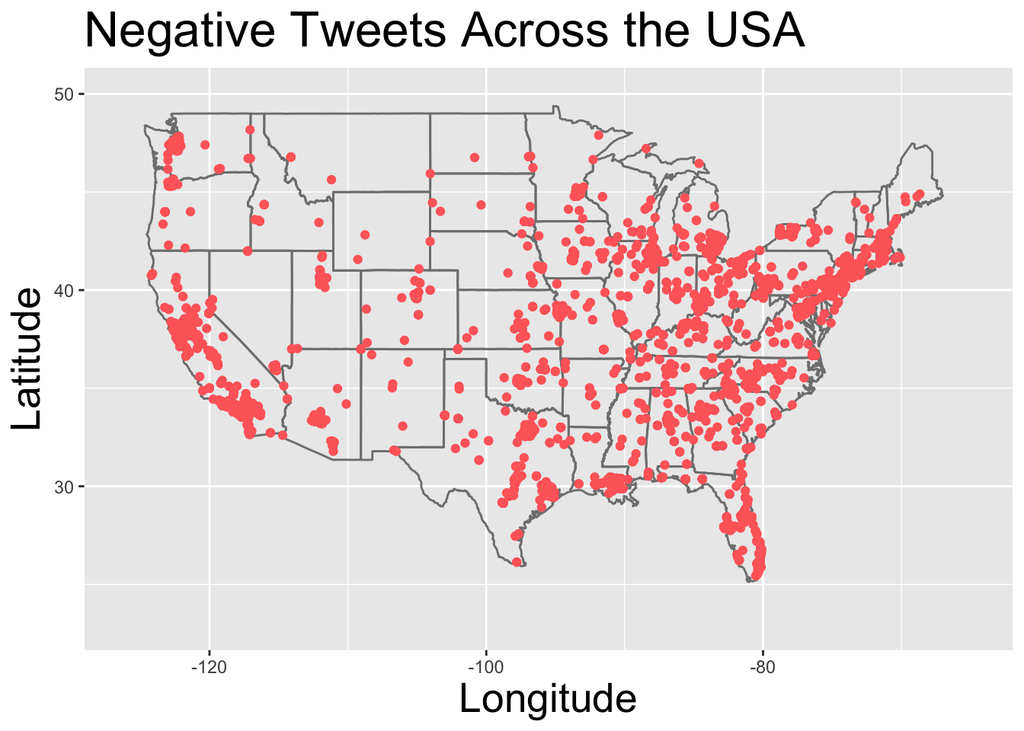

This graph shows the average polarity across the years regarding tweets about the issue. As you can see, on average, people feel more negatively about the topic overall, as the highest point on this graph is a polarity of about -0.05. However, there is an upward trend which shows that people may be warming up to the idea of paying college athletes afterall. The drop in the graph around November could show that when the idea is actually brought up in a governmental sense, which is what happened when Newsom approved the California bill, people have changed their minds when it becomes a real possibility for college athletes to get paid.

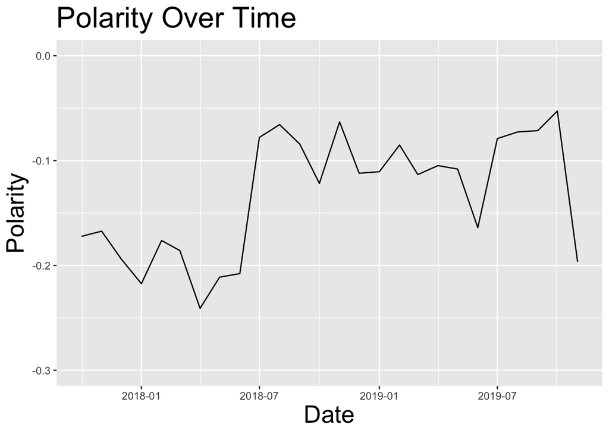

This graph shows political lean (based on where the tweet was sent from) compared to the polarity of the tweet. We defined political lean as number of Democratic House Representatives in that state compared to the number of Republican House Representatives in that state. A “lean” greater than 0.5 indicates a Democratic state and a “lean” less than 0.5 indicates a Republican state. We can see that for our Democratic and Republican-classified tweets, the boxplots are nearly identical, but Republican states have a slightly less negative attitude toward our topic. This is hinting to us that political lean does not have a strong relationship with attitude towards college athletes getting paid. If we were to take this slight difference and run with it, though, we could make sense of this result. Democratic people are probably more likely to oppose paying college athletes because many see it as unfair and an immoral monetization of college sports. Republican people may be more likely to support this simply due to the monetization.

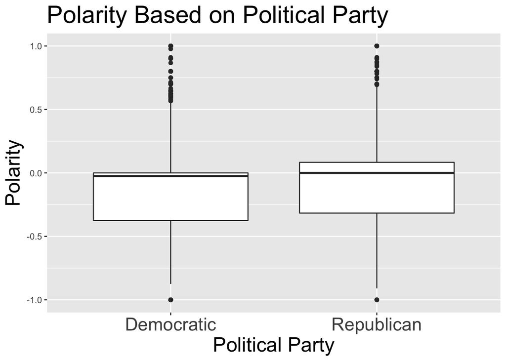

Since there was no true relation between attitude towards the topic and our definition of political lean, we decided to look at whether states who value certain sports are more supportive of the topic. From this website (https://fanbuzz.com/national/us-most-popular-sports/), we were able to find the most popular sport in each state. Using this classfication, we can see in these boxplots that states whose most popular sport is basketball have a slightly more negative attitude towards college athletes getting paid.

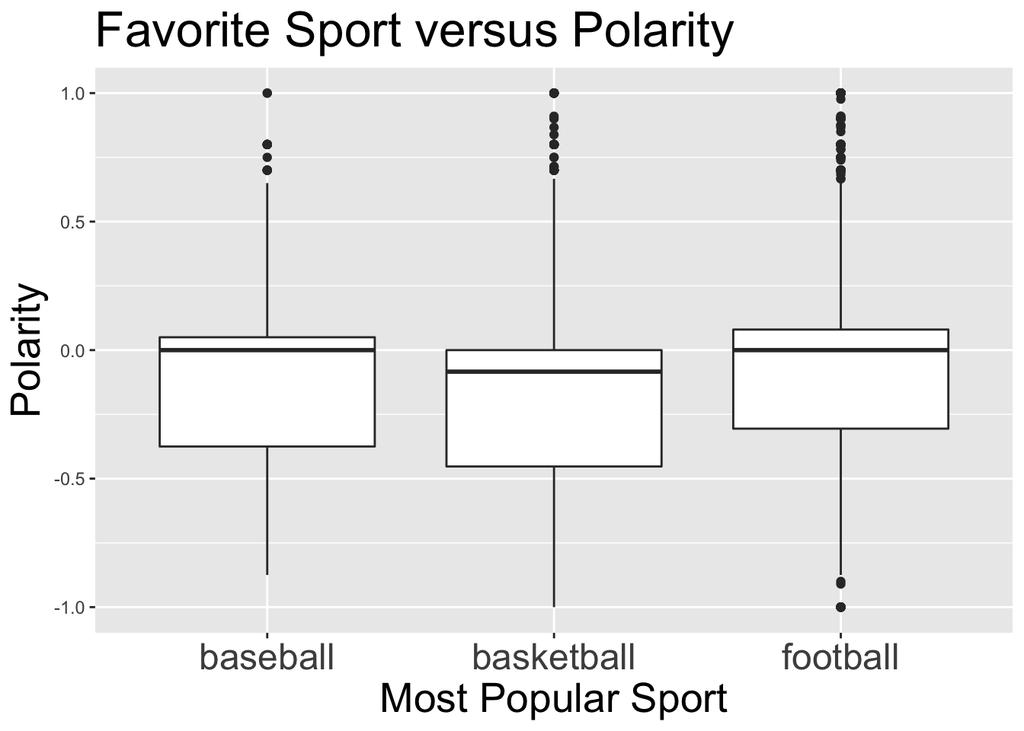

A simpler representation of this data can be seen in a basic bar graph that shows the average polarity based on most popular sport. Basketball states have an average polarity of -0.18, baseball states have an average polarity -0.11, and football states have an average polarity of -0.09.

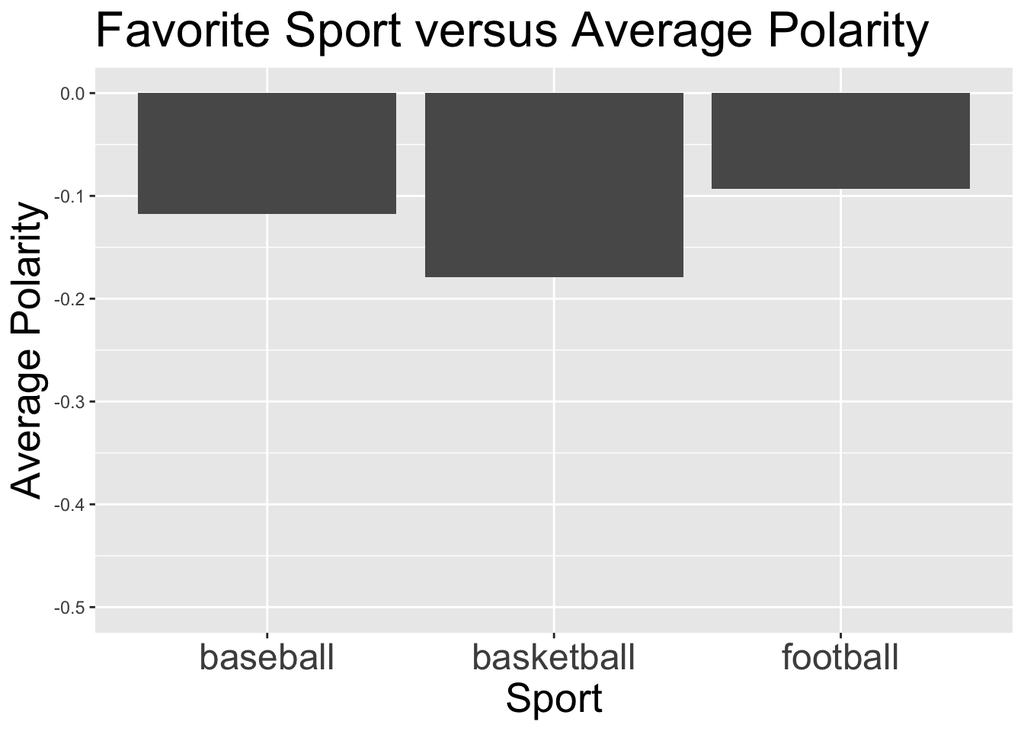

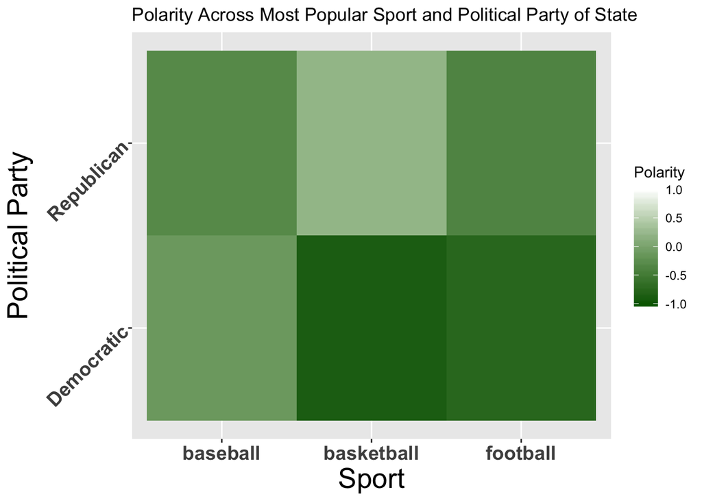

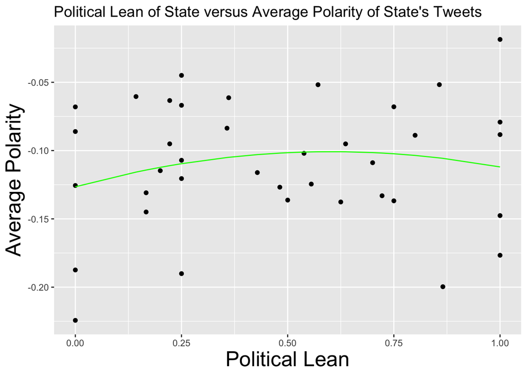

# Estimation Procedure

In our initial model, we started by analyzing the relationship between the polarity of each tweet, with regards to paying student athletes, and the political leanings of the state where the tweet originated. In this model, the independent variable is the political leaning of each state, and the dependent variable is the polarity of each tweet with regards to paying student atheletes. As you can see from the figure, there is almost no correlation between these variables. Based off of the regression, we can say that a 0.1 increase in our politcal leaning will decrease the polarity by 0.01124. Meaning the more democratic a state is, the less they agree with paying student athletes. This model only explains .7203% of the variability in the data. We also calculated a root mean squared error of 0.37788529, meaning most of the actual values fall within +/- 0.37788529 of the predicted values. This model is awful. This is a scatter plot of the data set and the predicted line:

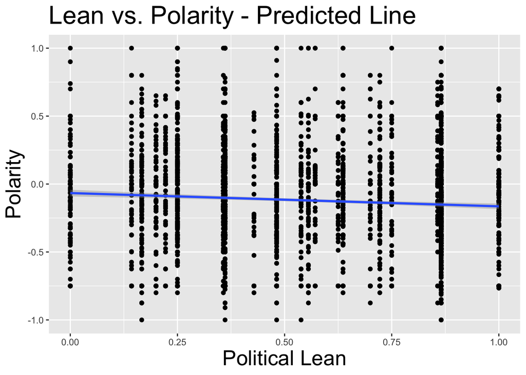

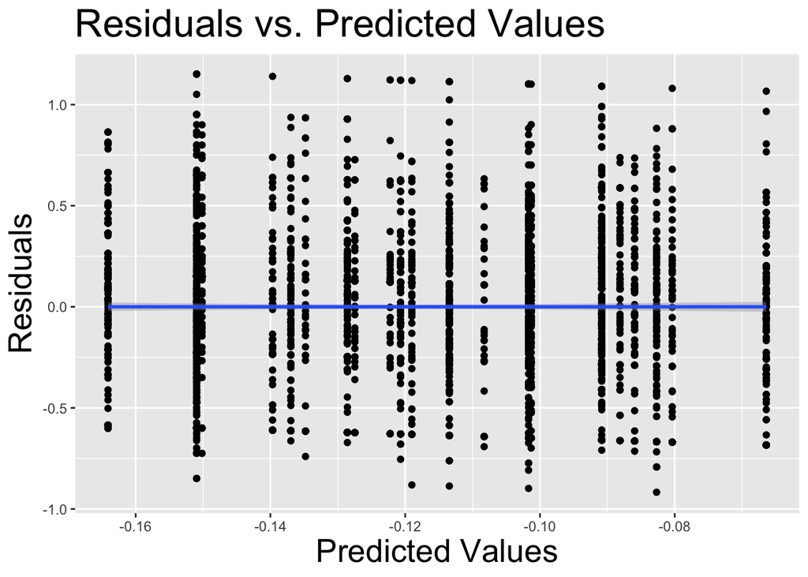

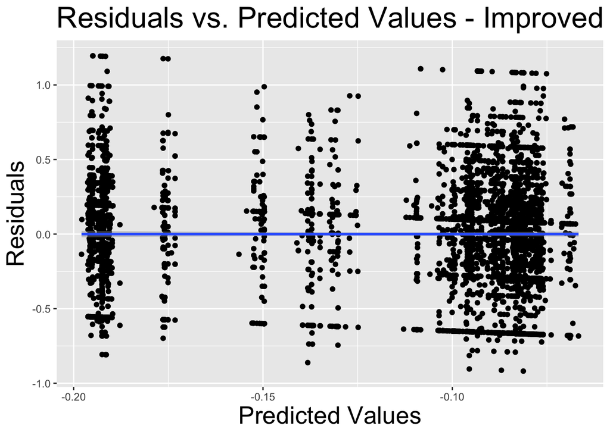

# Technical Appendix

1. In order to gather our data from twitter, we created a python script to pull the data from the server, using keywords. In order to lower our number of needed keywords, we changed all characters to lowercase. These keywords and phrases were words we believed were relevant to our topic. For example, we chose “pay student athletes”, “college athletes to hire agents”, “pay to play bill”, and others very relevant to our topic.
2. In order to create our models, we used the caret package in R.
3. For the models, we used a data partition. We used a 60% partition for both of our regressions. This resulted in our data set being 4310 tweets.
4. We first used a single regression model, using the ratio of democratic to republican representatives per each individual state. 1 being all democratic, and 0 being all republican. We had an R-squared of about .0072 depending on the random dataset we used to train with.
5. We then ran a multiple regression model, adding the tweets longitude and latitude coordinates, the favored sport in the state, and the overall political party of the state. We had an R-squared of about .0171 depending on the random dataset we used to train.
6. After each of the regressions, we tested the accuracy of the models on the validation set. We did this by running the model on the independent variable of the validation dataset to predict the polarity of 2872 tweets. I then calculated the Root Mean Squared Error by using the function postResample() that is in the caret package.
7. While our data did not show us any strong relationships between political lean and attitude towards paying college athletes, we were still able to make interesting conclusions. Since this is a very niche topic, we had difficulty gathering a large dataset of tweets. This topic is simply not discussed as often on Twitter as we thought! This small dataset (about 8,500 tweets) caused us to have a smaller n, which we know increases our estimation error. In order to combat this, we increased the number of dimensions by adding more variables into our model, which decreases the bayes error.